# RR2 first draft

Author

Chita Chaaban

Published

January 1, 2026

## Research Report 2: Does economic instability change one’s ability to act on climate change?

### Introduction

In 2020, in response to the COVID-19 pandemic, the European Commission proposed NextGenerationEU; a €750 billion recovery plan aimed at making Europe greener, more digital, and more resilient (European Commission, 2020). The plan is organized around five priority areas: Make it Green, Make it Digital, Make it Healthy, Make it Strong, and Make it Equal. But to design effective policies, they should be evidence based and supported by data. Therefore Infra4NextGen was launched in March 2024 and funded by the European Commission, it brings together outputs from key social science research infrastructures to inform the NextGenerationEU programme. The project is coordinated by the European Social Survey (ESS ERIC) and collects new cross-national data through the CRONOS-3 panel which is an online survey run across eleven European countries, organized by the five NextGenerationEU themes (Infra4NextGen, 2024).

Although this is an interesting approach to gathering evidence; the five themes chosen are not as independent as the project explores them. Attitudes on one topic are often shaped by conditions that belong to another. For example, access to digital tools could contribute to shaping one’s health literacy (Make it Digital × Make it Healthy). At a broader theoretical level, attitudes and beliefs are rarely held in isolation. Individuals tend to organize their opinions into interconnected belief systems, such that positions on one issue are often related to positions on others. This means that treating themes as analytically separate risks overlooking the consistency, spillover, and mutual reinforcement that can exist across domains (Blankenship et al., 2015). Brandt and Sleegers (2021) make a similar point at the political level, arguing that belief systems are better understood as dynamic networks of interconnected believes than as independent opinions. By focusing on these interconnections, the present report offers a cross-theme analysis attentive to the relational structure of attitudes rather than assuming that each theme operates independently

**Research Question and Hypotheses**

The environment is in crisis, and Europeans largely know it. According to the Special Eurobarometer on Climate Change, 93% of EU citizens believe climate change is a serious problem, and 88% agree that greenhouse gas emissions should be reduced to a minimum. Concern is widespread, but concern alone does not produce action, and something is blocking the gap between the two.

There are many reasons for this. One that gets less attention is people’s perceived ability to act. Acting on climate change is rarely free, it takes time, money, and a sense that what you do matters. We argue that when people are economically insecure, this perceived ability to act shrinks. Green products cost more. Sustainable choices require planning ahead. And when one is worried about making rent or keeping a job, thinking about long-term collective problems like climate change can feel genuinely out of reach. This could be explained through present bias, where when immediate survival takes priority, long-term threats feel less urgent and less actionable (Jaglan & Shergill, 2024; Camp, 2022). So the question this paper asks is: **how does economic insecurity shape individuals’ perceived ability to act on climate change?**

Our prediction of the answer to this research question is building on scarcity theory (Mullainathan & Shafir, 2020). It argues that individuals facing financial hardship have reduced cognitive and motivational bandwidth to engage with long-term collective problems. Thus when meeting basic needs feels uncertain, climate action may feel unreachable.

**H1: Higher perceived economic insecurity is associated with lower climate self-efficacy (**perceived ability to act against climate change)**, even after controlling for climate concern.**

If this hypothesis is confirmed, then the findings would be important especially when designing an intervention or policy, because if green taxes and eco-friendly options are less accessible to those in financial hardship, and if economic insecurity also undermines the sense of agency needed to act; then green policies that ignore inequality risk deepening the very disengagement they’re trying to address.

### Data and Preparation

**Data:**

```r
# Load packages
library(tidyverse)


# Load dataset
data <- read_delim(
  "C:/Users/ADMIN/Desktop/DAT505/RR2/ESS.csv",
  delim = ";",
  escape_double = FALSE,
  trim_ws = TRUE
)
```

**Main Variables:**

The main independent variable is perceived economic insecurity, constructed from four survey items (w2eq15–w2eq18), which are later combined into a single index.

The outcome of interest is perceived ability to act on climate change, measured primarily through climate self-efficacy, with climate fatalism used as an alternative measure capturing the same concept from the opposite direction.

Climate worry is included as a control variable to separate general concern about climate change from perceived ability to act. Additional socio-demographic controls (age, gender, education, and country) are included to account for potential confounding factors.

**Data preparation:**

First, missing values were recoded following the CRONOS-3 coding scheme. Non-substantive responses use variable-specific numeric codes. Most variables use a single-digit code: 9 for no answer, which was recoded to NA. The exception is eduyrs, which uses two-digit codes (77 for refusal, 88 for don’t know, 99 for no answer), and w2gq12, which uses 99 for no answer given its 0–10 scale. Income perception (hincfel) uses three single-digit codes: 7 for refusal, 8 for don’t know, and 9 for no answer. Age uses 999 for not available. All of these were recoded to NA before analysis.

We then created the main variables for the analysis. Climate efficacy (w2gq12) was kept as the main outcome variable, and climate fatalism (w2gq8) was retained as an alternative measure. An index of economic insecurity was then constructed by taking the average of four items capturing perceived risks of financial hardship (w2eq15–w2eq18), ignoring missing values. This index is meant to provide us with a continuous measure of perceived economic vulnerability, where higher values indicate greater insecurity.

The other variables like climate worry, age, years of education, gender, country, and income perception, were kept as controls, with gender, country, and income perception converted to categorical variables.

Finally, we reduced the dataset to only the variables relevant to the analysis, and dropped any observations with missing values on any of these variables. This gives us a clean, consistent sample across all models.

```r
# 1. Convert relevant variables to numeric
data <- data %>%
  mutate(across(
    c(w2gq12, w2gq8, w2gq1,
      w2eq15, w2eq16, w2eq17, w2eq18,
      hincfel, age, eduyrs),
    as.numeric
  ))

# 2. Recode missing values according to CRONOS-3 codebook
data <- data %>%
  mutate(
    # 0-10 scale, missing = 99 only
    w2gq12  = ifelse(w2gq12 == 99, NA, w2gq12),

    # 1-5 scale, missing = 9 only
    w2gq8   = ifelse(w2gq8 == 9, NA, w2gq8),
    w2gq1   = ifelse(w2gq1 == 9, NA, w2gq1),
    w2eq15  = ifelse(w2eq15 == 9, NA, w2eq15),
    w2eq16  = ifelse(w2eq16 == 9, NA, w2eq16),
    w2eq17  = ifelse(w2eq17 == 9, NA, w2eq17),
    w2eq18  = ifelse(w2eq18 == 9, NA, w2eq18),

    # hincfel: 7 = refusal, 8 = don't know, 9 = no answer
    hincfel = ifelse(hincfel %in% c(7, 8, 9), NA, hincfel),

    # eduyrs: 77 = refusal, 88 = don't know, 99 = no answer
    eduyrs  = ifelse(eduyrs %in% c(77, 88, 99), NA, eduyrs),

    # gndr: 9 = no answer
    gndr    = ifelse(gndr == 9, NA, gndr),

    # age: 999 = not available
    age     = ifelse(age == 999, NA, age)
  )

# 3. Create key variables
data <- data %>%
  mutate(
    climate_efficacy   = w2gq12,
    climate_fatalism   = w2gq8,
    econ_insecurity    = rowMeans(select(., w2eq15:w2eq18), na.rm = TRUE),
    climate_worry      = w2gq1,
    gender             = factor(gndr),
    country            = factor(cntry),
    Income_perception  = factor(hincfel)
  )

# 4. Keep only relevant variables
data_clean <- data %>%
  select(
    climate_efficacy,
    climate_fatalism,
    econ_insecurity,
    w2eq15,
    Income_perception,
    climate_worry,
    age,
    eduyrs,
    gender,
    country
  )

# 5. Drop missing values
data_clean <- data_clean %>%
  drop_na()

view(data_clean)
```

We must assess whether the four items used to construct the economic insecurity index formed a coherent scale. So to test their internal consistency we are using Cronbach’s alpha

```r
 # Cronbach's Alpha for the economic insecurity index

library(psych)

econ_items <- data %>%
  select(w2eq15, w2eq16, w2eq17, w2eq18)

alpha_econ <- psych::alpha(econ_items)

alpha_econ$total$raw_alpha
```

```
[1] 0.7227844
```

### **Descriptive statistics:**

```r
# Create basic descriptive table
desc_table <- data_clean %>%
  summarise(
    climate_efficacy  = mean(climate_efficacy, na.rm = TRUE),
    econ_insecurity   = mean(econ_insecurity, na.rm = TRUE),
    Income_perception = mean(Income_perception, na.rm = TRUE),
    climate_worry     = mean(climate_worry, na.rm = TRUE),
    age               = mean(age, na.rm = TRUE),
    eduyrs            = mean(eduyrs, na.rm = TRUE)
  ) %>%
  pivot_longer(everything(), names_to = "Variable", values_to = "mean") %>%
  mutate(
    sd = c(
      sd(data_clean$climate_efficacy, na.rm = TRUE),
      sd(data_clean$econ_insecurity, na.rm = TRUE),
      sd(data_clean$hincfel, na.rm = TRUE),
      sd(data_clean$climate_worry, na.rm = TRUE),
      sd(data_clean$age, na.rm = TRUE),
      sd(data_clean$eduyrs, na.rm = TRUE)
    )
  )
desc_table
```

```
# A tibble: 6 × 3
  Variable           mean     sd
  <chr>             <dbl>  <dbl>
1 climate_efficacy   5.28  2.53
2 econ_insecurity    2.69  1.02
3 Income_perception NA    NA
4 climate_worry      3.41  0.893
5 age               65.6  14.9
6 eduyrs            12.4   4.00
```

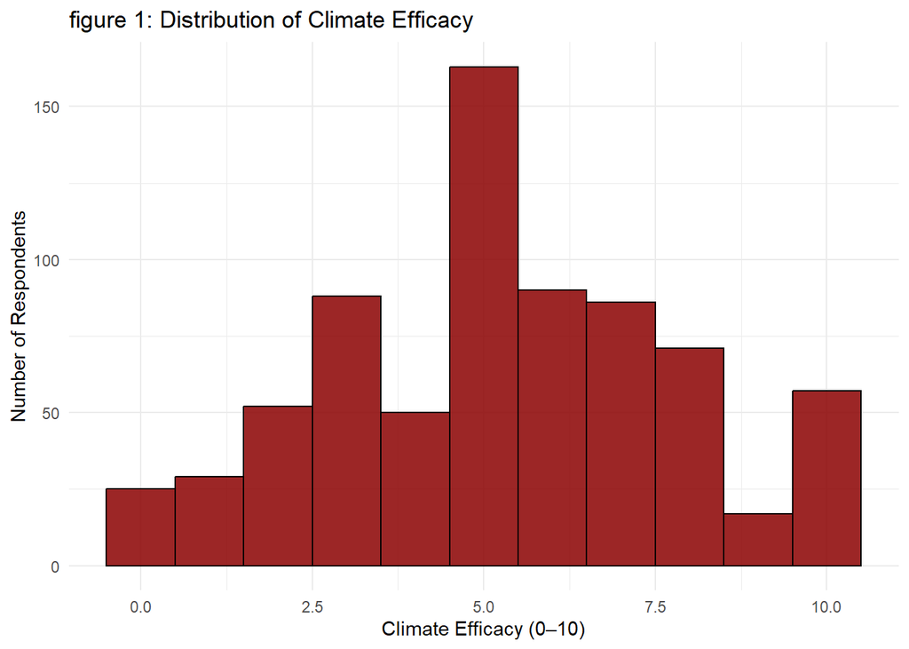

```r
# Create plot: climate efficacy
p1 = ggplot(data_clean, aes(x = climate_efficacy)) +
  geom_histogram(binwidth = 1,
                 fill = "darkred",
                 color = "black",
                 alpha = 0.85) +
  labs(title = "figure 1: Distribution of Climate Efficacy",
       x = "Climate Efficacy (0–10)",
       y = "Number of Respondents") +
  theme_minimal()
p1
```

Figure 1 shows that Climate efficacy is roughly bell-shaped, centred around 5 on the 0–10 scale. Most respondents place themselves in the middle range, which tells us that perceived climate agency is neither particularly high nor particularly low in this sample; perhaps participants are uncertain so they opt for a moreso neutral response.

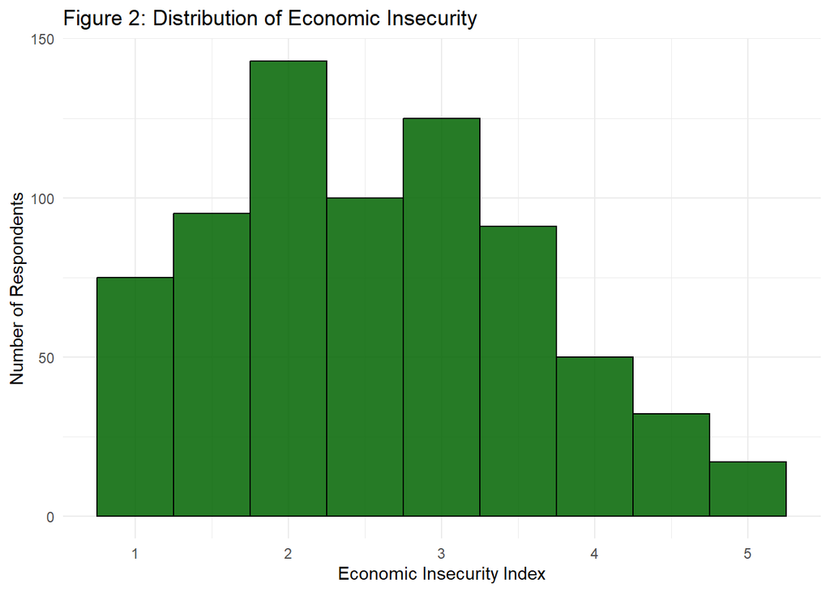

```r
# Create plot: economic insecurity
p2 = ggplot(data_clean, aes(x = econ_insecurity)) +
  geom_histogram(binwidth = 0.5,
                 fill = "darkgreen",
                 color = "black",
                 alpha = 0.85) +
  labs(title = "Figure 2: Distribution of Economic Insecurity",
       x = "Economic Insecurity Index",
       y = "Number of Respondents") +
  theme_minimal()
p2
```

Figure 2 showcases that Economic insecurity is right-skewed: most respondents clustering at the lower end of the 1–5 scale. This means the majority of people in our sample perceive themselves as relatively financially secure, with fewer respondents reporting high levels of insecurity.

[figure not shown]

```r
# Scatter plot with linear trend
p3 = ggplot(data_clean, aes(x = econ_insecurity, y = climate_efficacy)) +
  geom_point(alpha = 0.2,
             color = "darkblue",
             size = 1.5) +
  geom_smooth(method = "lm",
              color = "orange",
              fill = "black",
              alpha = 0.2,
              linewidth = 1.2) +
  labs(title = "Economic Insecurity and Climate Efficacy",
       subtitle = "Higher insecurity is associated with lower perceived agency",
       x = "Economic Insecurity",
       y = "Climate Efficacy") +
  theme_minimal()
p3
```

The scatter plot shows a weak positive relationship between economic insecurity and climate efficacy, as indicated by the upward-sloping regression line. This suggests that, at the bivariate level, higher economic insecurity is not associated with lower perceived agency, and if anything, the relationship appears slightly positive.

However, the relationship is relatively flat and the data are widely dispersed. Economic insecurity alone is not a strong predictor of perceived climate agency.

In relation to the hypothesis, these descriptive results do not provide clear support for the expected negative relationship. Instead, they highlight the need to account for additional factors, particularly climate worry, to better isolate the effect of economic insecurity on perceived agency.

### **Inferential stats:**

To test the hypothesis, I estimate a series of linear regression models that progressively introduce additional controls. I begin with a baseline model that examines the direct relationship between economic insecurity and climate self-efficacy. This allows me to assess whether there is any raw association between the two variables. I then add climate worry as a key control, in order to distinguish the effect of economic insecurity from general concern about climate change, which is likely to be strongly related to perceived ability to act. Finally, I estimate a full model that includes socio-demographic controls such as income perception, age, education, gender, and country. This step allows me to account for potential confounding factors and test whether the relationship between economic insecurity and climate efficacy holds once these characteristics are taken into account.

```r
library(modelsummary)
```

```r
# Model 1: Bivariate relationship
model1 <- lm(climate_efficacy ~ econ_insecurity, data = data_clean)

modelsummary(model1,
             output = "markdown",
             stars = TRUE,
             gof_map = c("nobs", "r.squared", "adj.r.squared"))
```

(Intercept)

4.565***

(0.264)

econ_insecurity

0.267**

(0.092)

Num.Obs.

728

R2

0.011

R2 Adj.

0.010

- p < 0.1, * p < 0.05, **p < 0.01,** * p < 0.001

The first model testing economic insecurity predicting climate efficacy, has a positive coefficient that is significant (B = 0.267, p < 0.01), which allows us to say that higher economic insecurity is actually associated with higher perceived climate efficacy, which goes against our hypothesis. R² = 0.011.

```r
# Model 2: Add climate worry (core control)
model2 <- lm(climate_efficacy ~ econ_insecurity + climate_worry, data = data_clean)

modelsummary(model2,
             output = "markdown",
             stars = TRUE,
             gof_map = c("nobs", "r.squared", "adj.r.squared"))
```

(Intercept)

2.169***

(0.418)

econ_insecurity

0.225*

(0.089)

climate_worry

0.735***

(0.101)

Num.Obs.

728

R2

0.078

R2 Adj.

0.076

- p < 0.1, * p < 0.05, **p < 0.01,** * p < 0.001

```r
# Model 3: Full model with controls
model3 <- lm(climate_efficacy ~ econ_insecurity + Income_perception + climate_worry +
               age + eduyrs + gender + country,
             data = data_clean)
modelsummary(model3,
             output = "markdown",
             stars = TRUE,
             gof_map = c("nobs", "r.squared", "adj.r.squared"))
```

(Intercept)

3.049***

(0.760)

econ_insecurity

0.099

(0.101)

Income_perception2

0.107

(0.224)

Income_perception3

-0.131

(0.326)

Income_perception4

0.194

(0.563)

climate_worry

0.640***

(0.102)

age

-0.008

(0.006)

eduyrs

-0.035

(0.024)

gender2

0.505**

(0.184)

countryBE

-0.022

(0.498)

countryCZ

0.486

(0.381)

countryFI

0.863+

(0.470)

countryFR

0.252

(0.561)

countryGB

0.167

(0.389)

countryHU

1.067*

(0.428)

countryIS

-0.630

(0.957)

countryPL

0.029

(0.357)

countryPT

1.602***

(0.475)

countrySI

0.540

(0.368)

Num.Obs.

728

R2

0.132

R2 Adj.

0.110

- p < 0.1, * p < 0.05, ** p < 0.01, *** p < 0.001

Model 3 adds all controls. The coefficient for economic insecurity drops to 0.099 and is no longer significant. Climate worry stays strong at 0.640 (p < 0.001). Income perception categories are all non-significant across the board. R²=0.132, the model explains 13.2 of the variation which is higher than all models tested so far.

### Robustness check:

Our hypothesis is about perceived climate agency, which we measured primarily through climate efficacy. But we also have a second measure of the same construct: climate fatalism (w2gq8), which captures whether people feel it is too difficult for someone like them to contribute. If economic insecurity matters for perceived agency, we should see it show up here too.

Reminder: For climate fatalism; the scale goes from 1 (agree it’s too difficult to act) to 5 (disagree strongly), so a negative coefficient means moving toward more fatalism: more feeling that action is out of reach.

```r
model4 <- lm(climate_fatalism ~ econ_insecurity + climate_worry +
               age + eduyrs + gender + country,
             data = data_clean)

modelsummary(model4,
             output = "markdown",
             stars = TRUE,
             gof_map = c("nobs", "r.squared", "adj.r.squared"))
```

(Intercept)

3.121***

(0.331)

econ_insecurity

-0.168***

(0.042)

climate_worry

0.140**

(0.045)

age

-0.008**

(0.003)

eduyrs

0.024*

(0.011)

gender2

0.069

(0.081)

countryBE

0.194

(0.219)

countryCZ

0.095

(0.168)

countryFI

0.161

(0.208)

countryFR

0.025

(0.247)

countryGB

-0.106

(0.170)

countryHU

0.109

(0.188)

countryIS

0.125

(0.420)

countryPL

-0.179

(0.157)

countryPT

0.067

(0.207)

countrySI

0.070

(0.161)

Num.Obs.

728

R2

0.079

R2 Adj.

0.060

- p < 0.1, * p < 0.05, **p < 0.01,** * p < 0.001

**Removing outliars for sensitivity checks:**

box plots:

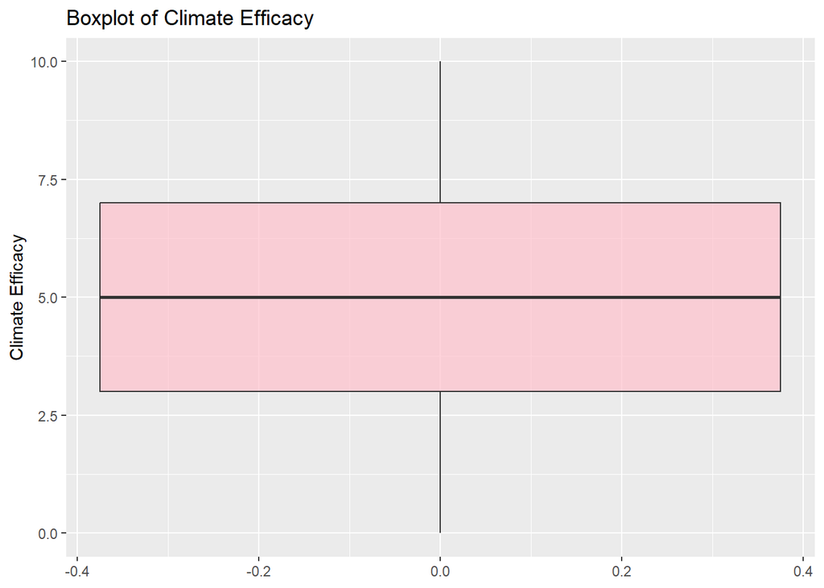

```r
# Boxplots to inspect potential outliers
ggplot(data_clean, aes(y = climate_efficacy)) +
  geom_boxplot(fill = "pink", alpha = 0.7) +
  labs(title = "Boxplot of Climate Efficacy",
       y = "Climate Efficacy")
```

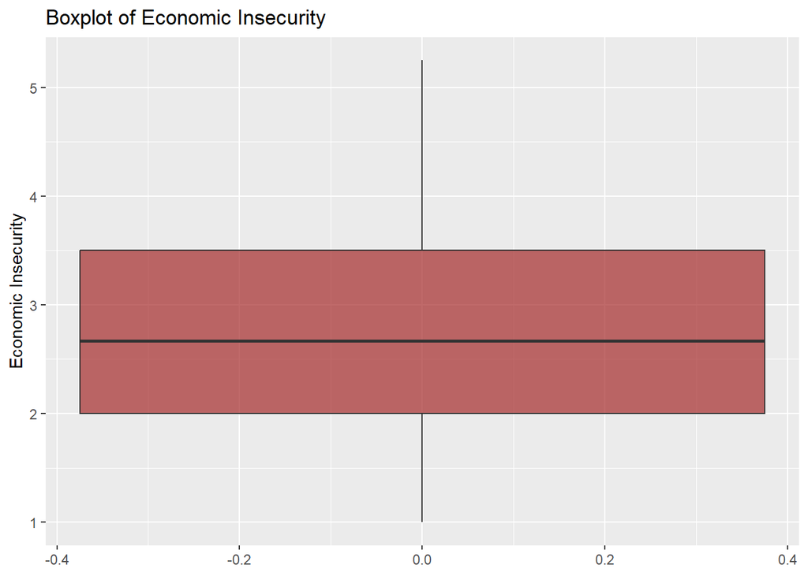

```r
ggplot(data_clean, aes(y = econ_insecurity)) +
  geom_boxplot(fill = "brown", alpha = 0.7) +
  labs(title = "Boxplot of Economic Insecurity",
       y = "Economic Insecurity")
```

Boxplots of the two main variables revealed no outliers in either climate efficacy or economic insecurity. All values fell within the expected range under the 1.5×IQR rule. An outlier-removal sensitivity check is therefore not applicable.

**Multiple imputation with MICE**

So far we have handled missing values by dropping any observation with a missing value on any variable (listwise deletion). This is simple but potentially biased if the data are not missing completely at random. As a check, we re-run the main model on a dataset where missing values are replaced using multiple imputation via the MICE package.

```r
library(mice)

# Select the variables we need from the original data object
data_for_mice <- data %>%
  select(w2gq12, w2gq8, w2gq1,
         w2eq15, w2eq16, w2eq17, w2eq18,
         hincfel, age, eduyrs, gndr, cntry) %>%
  mutate(
    climate_efficacy  = w2gq12,
    climate_fatalism  = w2gq8,
    climate_worry     = w2gq1,
    econ_insecurity   = rowMeans(select(., w2eq15:w2eq18), na.rm = TRUE),
    gender            = factor(gndr),
    country           = factor(cntry),
    Income_perception = factor(hincfel)
  ) %>%
  select(climate_efficacy, climate_fatalism, econ_insecurity,
         Income_perception, climate_worry, age, eduyrs, gender, country)

# Run imputation
set.seed(1234)
imputed <- mice(data_for_mice, m = 5, method = "pmm", printFlag = FALSE)

# Run the main model on each imputed dataset and pool
model_mice <- with(imputed,
                   lm(climate_efficacy ~ econ_insecurity + Income_perception +
                        climate_worry + age + eduyrs + gender + country))

pooled <- pool(model_mice)

# Display results
summary(pooled)
```

```
                 term     estimate   std.error  statistic         df
1         (Intercept)  1.973652381 0.210861156  9.3599619  49.392518
2     econ_insecurity  0.082875209 0.051098334  1.6218769   7.301905
3  Income_perception2  0.091226815 0.186463013  0.4892489   4.747059
4  Income_perception3  0.106211405 0.275164500  0.3859924   4.984222
5  Income_perception4  0.174963779 0.381671956  0.4584140   6.196574
6       climate_worry  0.620222091 0.029416344 21.0842681  49.953889
7                 age  0.008370691 0.001487456  5.6275217 403.004011
8              eduyrs -0.012782870 0.009664523 -1.3226591  11.358268
9             gender2  0.454244358 0.162660469  2.7925922   4.766272
10          countryBE -0.441068402 0.110357224 -3.9967334 589.871985
11          countryCZ  0.198797806 0.128316780  1.5492736  84.498550
12          countryFI  0.530088899 0.109444458  4.8434513 105.114116
13          countryFR  0.036835692 0.119534935  0.3081584 144.580541
14          countryGB -0.096414520 0.116813883 -0.8253687 110.259147
```

[output cut: 25 more lines]

The MICE results are very consistent with the main model, which is exactly what we want to see from a robustness check.

Economic insecurity remains non-significant (B = 0.083, p = 0.147), just like in model 3. So even when we use imputed data instead of dropping missing observations, the conclusion doesn’t change — economic insecurity does not significantly predict climate efficacy.

Climate worry is again the dominant predictor (B = 0.620, p < 0.001), confirming that this finding is stable regardless of how we handle missing data. Gender remains significant (B = 0.454, p < 0.05), with women reporting higher efficacy. Age is also significant here (B = 0.008, p < 0.001), though the effect is very small. Education is not significant.

On the country side, several countries are now significant with the larger imputed sample: Belgium is notably negative (B = -0.441, p < 0.001), while Finland (B = 0.530, p < 0.001), Hungary (B = 0.923, p < 0.001), Iceland (B = 0.333, p < 0.05), Portugal (B = 1.242, p < 0.001), and Slovenia (B = 0.231, p < 0.05) are all significantly different from the reference category. Imputation retains more observations so the model has more power to detect country differences.

=> Economic insecurity does not predict climate efficacy, and this is not an artifact of how we handled missing values.

Finally, to get a broader picture of how stable our results are across different model specifications, we use the specr package to run all reasonable combinations of outcomes, predictors, and controls at once and visualise the results in a specification curve.

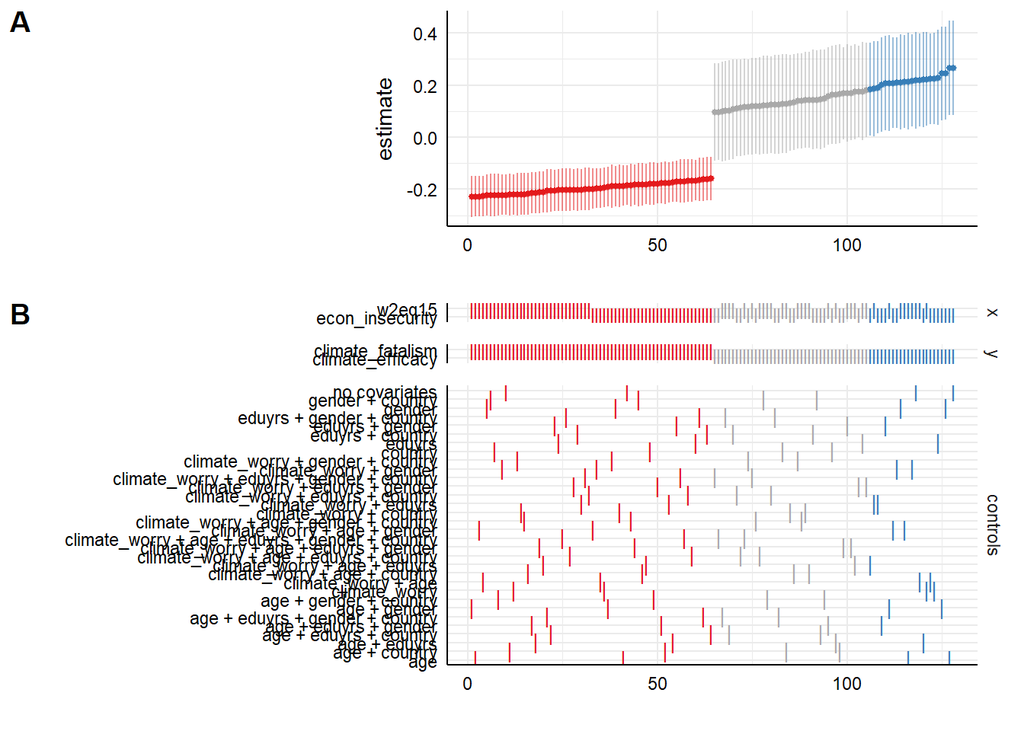

```r
library(specr)

# Run specr
setup_results <- setup(
  data = data_clean,
  y = c("climate_efficacy", "climate_fatalism"),
  x = c("econ_insecurity", "w2eq15"),
  model = c("lm"),
  controls = c("climate_worry", "age", "eduyrs", "gender", "country")
)

results <- specr(setup_results)

# Cleaner plot
plot(results,
     choices = c("x", "y", "controls"))
```

### **Predictive modelling**

To evaluate whether the model has predictive power beyond the sample used for estimation, I implement a series of predictive validation techniques.

**Train-test split for the main model:**

To see whether the main model from the analysis can predict new observations, not just fit the sample used to estimate it, we first split the data into a training set and a test set. Then we estimate the model on the training set, and then evaluate how well it predicts climate efficacy in the test set. Since the outcome is continuous, I use RMSE and R-squared to assess predictive performance.

```r
# Load the packages used for this section
library(caret)
library(knitr)

# Set a seed so the split is reproducible
set.seed(1234)

# Create an 80/20 train-test split
train_index <- createDataPartition(data_clean$climate_efficacy, p = 0.8, list = FALSE)

train_data <- data_clean[train_index, ]
test_data  <- data_clean[-train_index, ]

# Fit the main linear regression model on the training set
main_model_train <- lm(
  climate_efficacy ~ econ_insecurity + Income_perception + climate_worry +
    age + eduyrs + gender + country,
  data = train_data
)

# Predict climate efficacy in the test set
test_pred <- predict(main_model_train, newdata = test_data)

# Compute predictive performance
rmse_test <- RMSE(test_pred, test_data$climate_efficacy)
r2_test   <- R2(test_pred, test_data$climate_efficacy)

# Put the results into a small table
test_results <- data.frame(
  RMSE = rmse_test,
  R_squared = r2_test
)

# Display the table
kable(
  test_results,
  digits = 3,
  caption = "Predictive performance on the test set"
)
```

Predictive performance on the test set

| RMSE | R_squared |
| --- | --- |
| 2.553 | 0.087 |

The predictive performance of the model on the test set is relatively weak. The RMSE of 2.55 indicates that, on average, the model’s predictions deviate from the true climate efficacy scores by about 2.6 points. Given that the outcome is measured on a 0–10 scale, this represents a fairly large prediction error.

These results suggest that while the model may still be useful for identifying associations between variables (as in the inferential analysis), it performs poorly as a predictive tool. In other words, the variables included in the model, such as economic insecurity and climate worry, do not provide strong predictive power for accurately forecasting individual levels of climate efficacy.

**Cross-validated predictive performance of the main model:**

While the train-test split provides a first indication of predictive performance, it relies on a single random partition of the data. To obtain a more reliable estimate, I next use 10-fold cross-validation. This approach repeatedly divides the dataset into training and validation subsets, allowing the model to be evaluated across multiple data partitions rather than a single split.

```r
# Define cross-validation settings
train_control_cv <- trainControl(
  method = "cv",
  number = 10
)

# Train the model using 10-fold cross-validation
cv_model <- train(
  climate_efficacy ~ econ_insecurity + Income_perception + climate_worry +
    age + eduyrs + gender + country,
  data = data_clean,
  method = "lm",
  metric = "RMSE",
  trControl = train_control_cv
)

cv_results <- data.frame(
  Method = "10-fold Cross-Validation",
  RMSE = round(cv_model$results$RMSE, 3),
  R_squared = round(cv_model$results$Rsquared, 3),
  MAE = round(cv_model$results$MAE, 3)
)

kable(cv_results, caption = "Predictive performance: 10-fold cross-validation")
```

Predictive performance: 10-fold cross-validation

| Method | RMSE | R_squared | MAE |
| --- | --- | --- | --- |
| 10-fold Cross-Validation | 2.417 | 0.102 | 1.972 |

**Bootstrap validation**

To further assess the robustness of these findings, I implement bootstrap validation. Unlike cross-validation, which partitions the data into fixed folds, bootstrap validation repeatedly resamples the dataset with replacement, providing an alternative estimate of predictive performance.

```r
#Define bootstrap settings

train_control_boot <- trainControl( method = "boot", number = 100 )

#Train the model using bootstrap validation

boot_model <- train( climate_efficacy ~ econ_insecurity + Income_perception + climate_worry + age + eduyrs + gender + country, data = data_clean, method = "lm", metric = "RMSE", trControl = train_control_boot )

boot_results <- data.frame(
  Method = "Bootstrap (100 reps)",
  RMSE = round(boot_model$results$RMSE, 3),
  R_squared = round(boot_model$results$Rsquared, 3),
  MAE = round(boot_model$results$MAE, 3)
)

kable(boot_results, caption = "Predictive performance: bootstrap validation")
```

Predictive performance: bootstrap validation

| Method | RMSE | R_squared | MAE |
| --- | --- | --- | --- |
| Bootstrap (100 reps) | 2.471 | 0.079 | 2.014 |

The bootstrap validation results further confirm the limited predictive performance of the model. The RMSE is 2.47, which is very close to the value obtained through cross-validation. This indicates that the average prediction error remains substantial, with predicted values deviating from observed climate efficacy by roughly 2.5 points.

The MAE of 2.00 reinforces this conclusion, indicating that the average absolute prediction error remains around 2 points, which is considerable given the scale of the outcome variable.

The consistency of RMSE and MAE across validation methods, combined with persistently low R-squared values, suggests that the model’s limited predictive performance is robust. These results indicate that the predictors included in the model capture only a small portion of the variation in climate efficacy, regardless of the resampling strategy employed.

**A data-driven approach: lasso regression:**

The previous analyses evaluated the predictive performance of a theory-driven model. Now we extend the analysis by adopting a more data-driven approach. Specifically, we use lasso regression, which applies a penalty to the model coefficients and shrinks less informative predictors toward zero. This allows the model to identify a more parsimonious specification that may improve predictive performance.

```r
library(glmnet)
# Create predictor matrix with all relevant variables
x <- model.matrix(
  climate_efficacy ~ econ_insecurity + Income_perception + climate_worry +
    age + eduyrs + gender + country + climate_fatalism + w2eq15,
  data = data_clean
)[, -1]

y <- data_clean$climate_efficacy

set.seed(1234)

# Cross-validated lasso
cv_lasso <- cv.glmnet(
  x, y,
  alpha = 1,
  family = "gaussian",
  nfolds = 10
)

# Lambda values
kable(data.frame(
  Lambda_min = round(cv_lasso$lambda.min, 3),
  Lambda_1se = round(cv_lasso$lambda.1se, 3)),
  caption = "Cross-validated lambda values")
```

Cross-validated lambda values

| Lambda_min | Lambda_1se |
| --- | --- |
| 0.079 | 0.291 |

```r
# Non-zero coefficients at lambda.min
lasso_coefs <- as.data.frame(as.matrix(coef(cv_lasso, s = "lambda.min")))
lasso_coefs <- lasso_coefs %>%
  rownames_to_column("Predictor") %>%
  rename(Coefficient = 2) %>%
  filter(Coefficient != 0) %>%
  mutate(Coefficient = round(Coefficient, 3))

kable(lasso_coefs, caption = "Lasso coefficients at lambda.min (non-zero only)")
```

Lasso coefficients at lambda.min (non-zero only)

| Predictor | Coefficient |
| --- | --- |
| (Intercept) | 1.922 |
| econ_insecurity | 0.048 |
| climate_worry | 0.536 |
| eduyrs | -0.026 |
| gender2 | 0.371 |
| countryBE | -0.039 |
| countryFI | 0.184 |
| countryHU | 0.573 |
| countryIS | -0.303 |
| countryPL | -0.024 |
| countryPT | 1.072 |
| countrySI | 0.012 |
| climate_fatalism | 0.386 |
| w2eq15 | 0.118 |

```r
# Cross-validated RMSE
kable(data.frame(
  CV_RMSE = round(sqrt(min(cv_lasso$cvm)), 3)),
  caption = "Cross-validated RMSE of lasso model")
```

Cross-validated RMSE of lasso model

| CV_RMSE |
| --- |
| 2.376 |

The optimal penalty selected through cross-validation is λ = 0.079, which is relatively low, meaning only moderate shrinkage was needed to optimize predictive performance. The more conservative alternative, λ = 0.291, would shrink more predictors to zero but at the cost of higher prediction error.

Looking at the retained coefficients, several predictors were shrunk to exactly zero and dropped entirely (all income perception categories and age) meaning they add nothing once the other variables are in the model. Among the predictors that survived, climate worry is the strongest (0.536), confirming what we saw throughout the inferential analysis. Climate fatalism is also retained with a meaningful coefficient (0.386). Gender (0.371) and country differences, particularly Portugal (1.072) and Hungary (0.573), also contribute to prediction.

Economic insecurity is retained but with a very small coefficient (0.048), and w2eq15 similarly survives at 0.118. So while neither is shrunk to zero, their contribution to prediction is minimal compared to climate worry and fatalism.

**Predictive performance of the lasso model:**

To directly compare the predictive performance of the lasso model with the original specification, we evaluate it using the same train-test approach.

```r
set.seed(1234)

train_index <- createDataPartition(data_clean$climate_efficacy, p = 0.8, list = FALSE)
train_data  <- data_clean[train_index, ]
test_data   <- data_clean[-train_index, ]

# Predictor matrix for training data
x_train <- model.matrix(
  climate_efficacy ~ econ_insecurity + Income_perception + climate_worry +
    age + eduyrs + gender + country + climate_fatalism + w2eq15,
  data = train_data
)[, -1]

y_train <- train_data$climate_efficacy

# Predictor matrix for test data
x_test <- model.matrix(
  climate_efficacy ~ econ_insecurity + Income_perception + climate_worry +
    age + eduyrs + gender + country + climate_fatalism + w2eq15,
  data = test_data
)[, -1]

y_test <- test_data$climate_efficacy

# Fit lasso on training data with cross-validated lambda
cv_lasso_train <- cv.glmnet(
  x_train, y_train,
  alpha = 1,
  family = "gaussian",
  nfolds = 10
)

# Predict on test set
lasso_pred <- predict(cv_lasso_train, newx = x_test, s = "lambda.min")

# Performance metrics
rmse_lasso <- RMSE(as.numeric(lasso_pred), y_test)
r2_lasso <- R2(as.numeric(lasso_pred), y_test)

kable(data.frame(
  RMSE = round(rmse_lasso, 3),
  R_squared = round(r2_lasso, 3)),
  caption = "Predictive performance of lasso model on test set")
```

Predictive performance of lasso model on test set

| RMSE | R_squared |
| --- | --- |
| 2.469 | 0.137 |

The lasso model on the test set gives an RMSE of 2.469 and an R² of 0.137. Compared to the theory-driven model’s test set performance (RMSE = 2.553, R² = 0.087), this is a modest improvement: adding more variables and letting lasso select among them explains a bit more variance and reduces prediction error slightly. However, the improvement is small and the overall picture is the same: predictions still deviate from true climate efficacy scores by about 2.5 points on average, and the model still leaves most of the variance unexplained. The cross-validated RMSE of 2.376 is slightly more optimistic than the test set result. Overall, neither the theory-driven nor the data-driven approach produces a model with strong predictive power, which suggests that the variables available in this dataset, economic, demographic, and basic attitudinal measures; are not sufficient to accurately predict individual-level climate efficacy.

**Discussion and conclusion**

A better predictive model would not necessarily involve a different estimation technique, but rather the inclusion of more theoretically relevant predictors that capture the psychological and behavioral dimensions of climate efficacy. The current results suggest that economic and demographic variables alone are insufficient to accurately predict individual-level variation in climate efficacy.

**References**

European Commission. (2020). Recovery plan for Europe.https://commission.europa.eu/strategy-and-policy/recovery-plan-europe_en

European Commission. (2023). Special Eurobarometer 538: Climate change.https://cyprus.representation.ec.europa.eu/news/eurobarometer-majority-europeans-consider-green-transition-should-go-faster-2023-07-20_en

Infra4NextGen. (2024). About Infra4NextGen.https://infra4nextgen.com/about-infra4nextgen/

Mullainathan, S., & Shafir, E. (2020). Scarcity: Why having too little means so much. Picador.

Jaglan, M., & Shergill, A. (2024). People’s decisions matter: an empirical examination of behavioral contributors of poverty. Journal of Poverty, 29(3), 257–276. https://doi.org/10.1080/10875549.2024.2379778

Camp, S. (2022). Delay discounting and financial insecurity: Evidence from behavioral economic experiments. **Journal of Behavioral and Experimental Economics**, 97, 101847.